# Missing Data Analysis

William Murrah

## Packages we will use:

```r
require(texreg)
require(mice)
require(VIM)
require(ztable)
```

```r
doctype <-
   # "latex"
   "html"
txreg <- ifelse(doctype == "latex", texreg, htmlreg)
options(ztable.type = doctype)
```

## Notation we will use:

- $n$ = number of units (number of cases or people) indexed by $i$.
- $p$ = number of variables (including outcome and predictors), indexed by $j$.
- $Y$ = $n\times p$ matrix containing the data values on $n$ units for $p$ variables in the sample.
- $R$ = response indicator, a $n\times p$ matrix with each cell containing either a `0` or a `1`, where

$r_{ij} = \begin{cases} \text{1 if $y_{ij}$ is observed and,} \\ \text{0 if $y_{ij}$ is missing.} \end{cases} \tag{1}$

- $Y_{obs}$ = the observed data, collectively (i.e. contains all elements $y_{ij}$ where $r_{ij} = 1$).
- $Y_{mis}$ = the missing data, collectively (i.e. contains all elements $y_{ij}$ where $r_{ij} = 0$).

## Missing Data Patterns

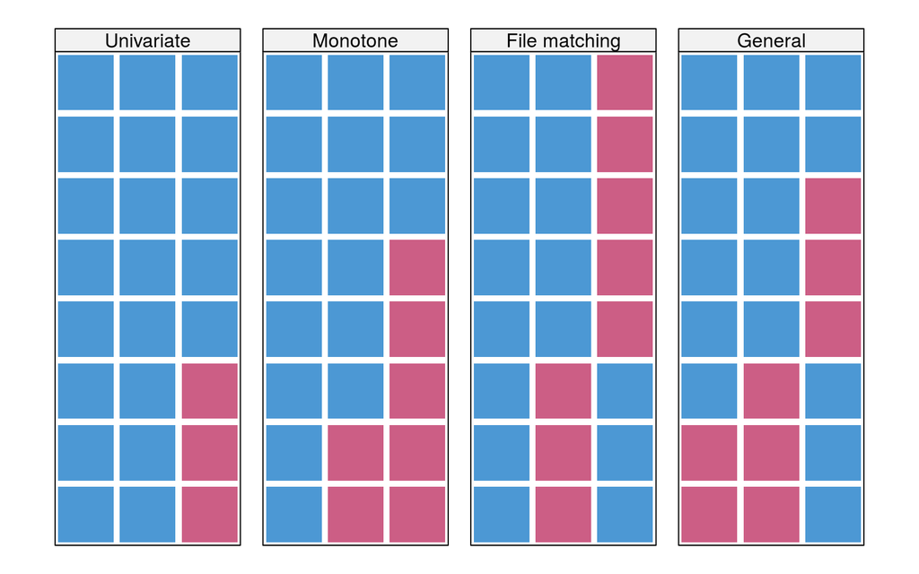

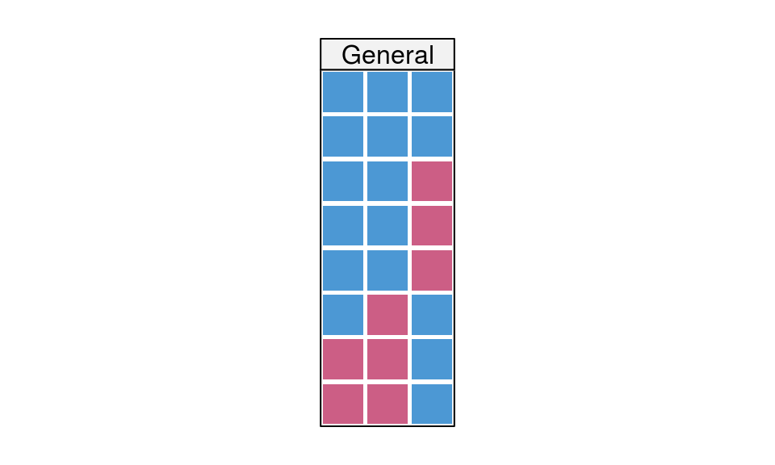

```r
print(tp41[4])
```

## A simple data frame with some missing data:

```r
general
```

```
   A  B  C
1 22 50 17
2 82 76 90
3 53 18 NA
4 92 85 NA
5 84 87 NA
6  5 NA 14
7 NA NA 11
8 NA NA 52
```

### Create an $R$ matrix

```r
R <- 1 - is.na(general)
R
```

```
  A B C
1 1 1 1
2 1 1 1
3 1 1 0
4 1 1 0
5 1 1 0
6 1 0 1
7 0 0 1
8 0 0 1
```

```r
md.pattern(pattern4)
```

```
  A B C
2 1 1 1 0
1 1 0 1 1
3 1 1 0 1
2 0 0 1 2
  2 3 3 8
```

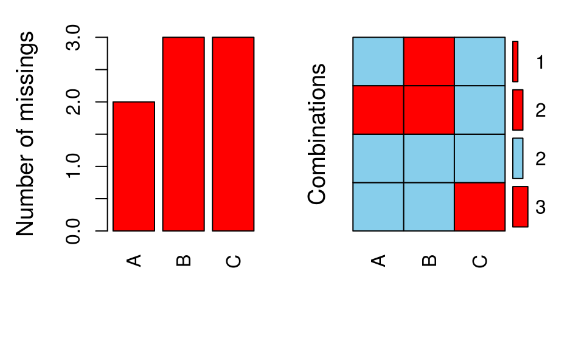

```r
aggr(general, numbers = TRUE, prop = FALSE)
```

## Proportion of usable cases

Imputing $Y_j$ from $Y_k$, the *proportion of usable cases* is the number of cases missing in $Y_j$ that are observed in $Y_k$ divided by the number of missing cases in $Y_j$.

```r
p <- md.pairs(general)
p$mr/(p$mr + p$mm) # proportion of usable cases.
```

```
          A B C
A 0.0000000 0 1
B 0.3333333 0 1
C 1.0000000 1 0
```

## Influx and Outflux

Influx - $I_j$ the *influx coefficient* is how well the other variables connect to $Y_j$.

- $I_j$ is `0` for a completely observed variable
- $I_j$ is `1` for a completely missing variable

Outflux - $O_j$ the *outflux coefficient* is how well $Y_j$ is connected to other variables.

- $O_j$ is `1` for a completely observed variable
- $O_j$ is `0` for a completely missing variable

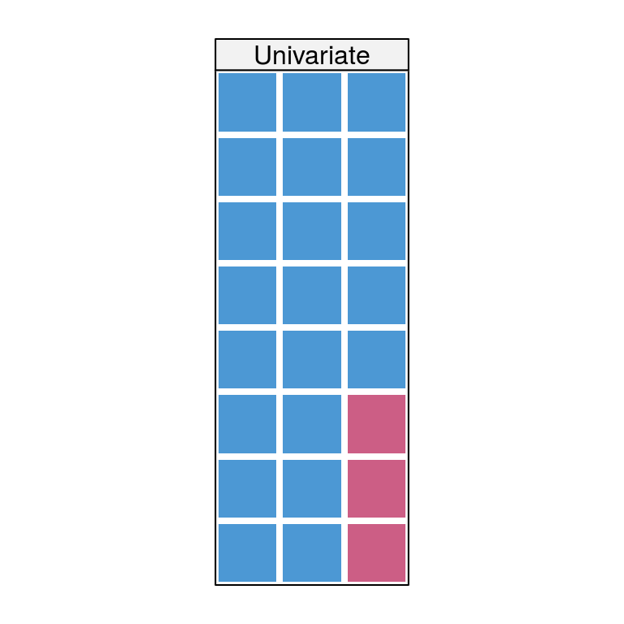

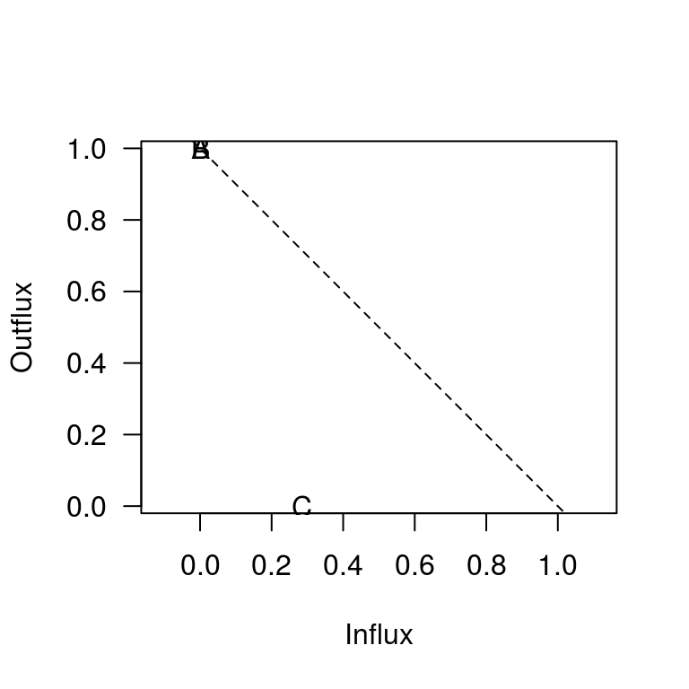

```r
print(tp41[1])
fluxplot(pattern1, main = NULL)
```

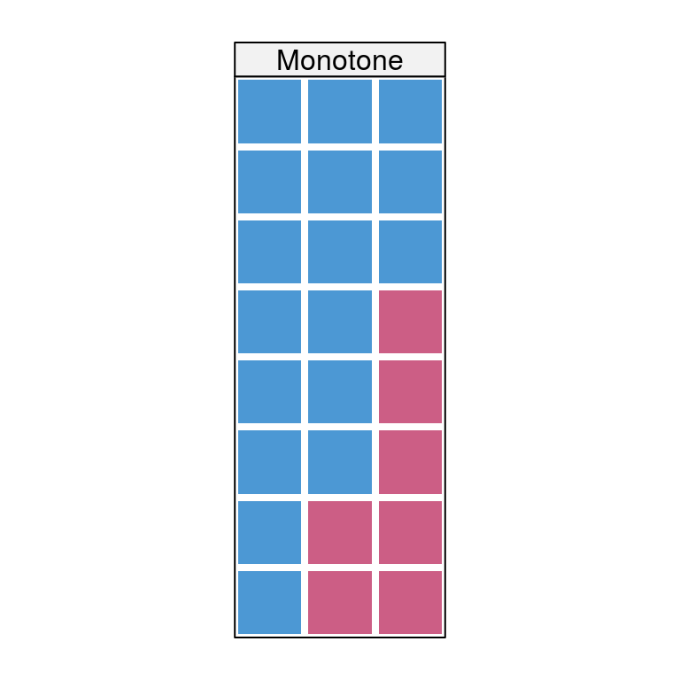

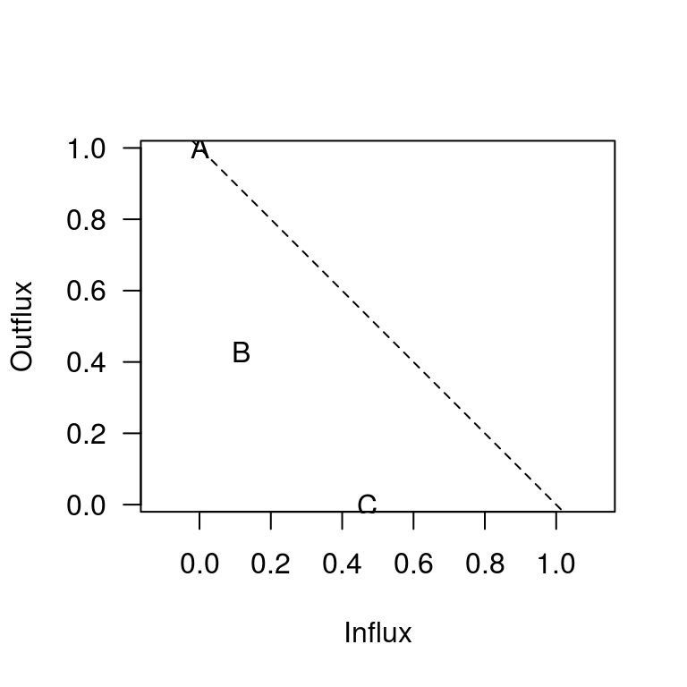

```r
print(tp41[2])
fluxplot(pattern2, main = NULL)
```

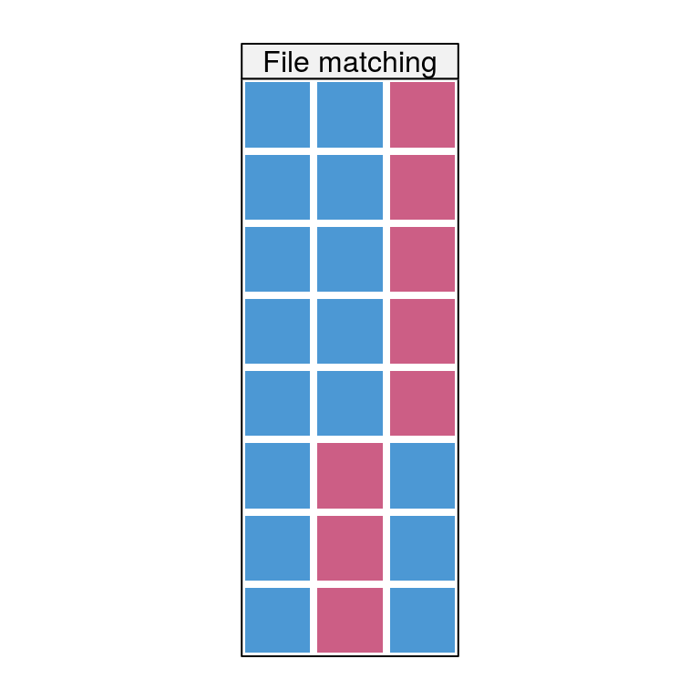

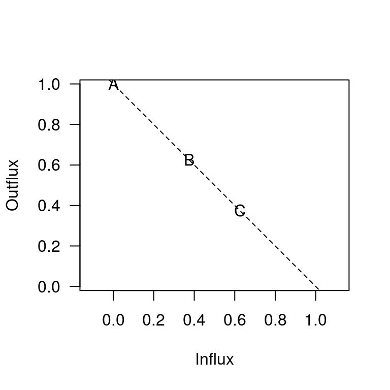

```r
print(tp41[3])
fluxplot(pattern3, main = NULL)
```

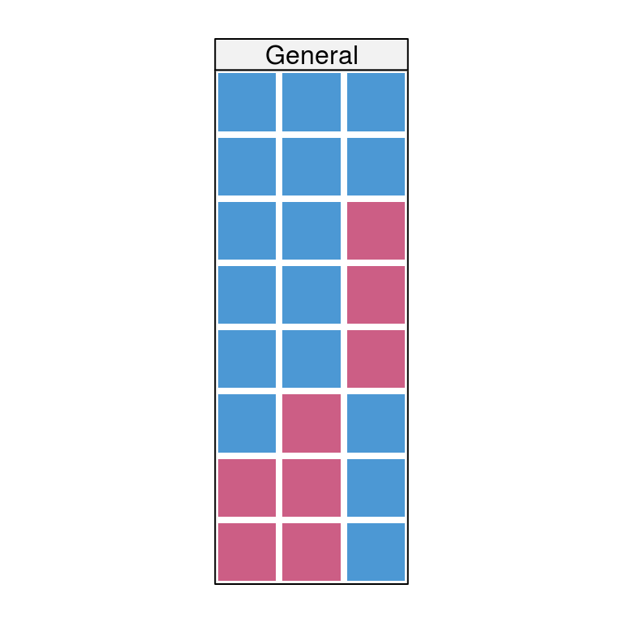

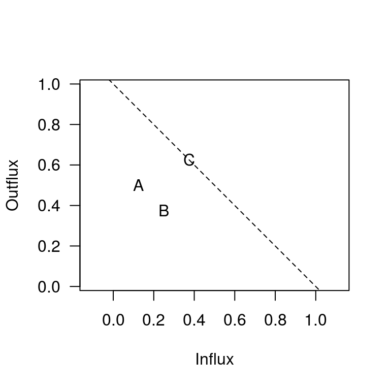

```r
print(tp41[4])
fluxplot(general, main = NULL)
```

# Missing Data Analysis

## Data we will use:

```r
#  ?nhanes
data("nhanes2")
ztable(nhanes)
```

|  | age | bmi | hyp | chl |
| --- | --- | --- | --- | --- |
| 1 | 1.00 |  |  |  |
| 2 | 2.00 | 22.70 | 1.00 | 187.00 |
| 3 | 1.00 |  | 1.00 | 187.00 |
| 4 | 3.00 |  |  |  |
| 5 | 1.00 | 20.40 | 1.00 | 113.00 |
| 6 | 3.00 |  |  | 184.00 |
| 7 | 1.00 | 22.50 | 1.00 | 118.00 |
| 8 | 1.00 | 30.10 | 1.00 | 187.00 |
| 9 | 2.00 | 22.00 | 1.00 | 238.00 |
| 10 | 2.00 |  |  |  |
| 11 | 1.00 |  |  |  |
| 12 | 2.00 |  |  |  |
| 13 | 3.00 | 21.70 | 1.00 | 206.00 |
| 14 | 2.00 | 28.70 | 2.00 | 204.00 |
| 15 | 1.00 | 29.60 | 1.00 |  |
| 16 | 1.00 |  |  |  |
| 17 | 3.00 | 27.20 | 2.00 | 284.00 |
| 18 | 2.00 | 26.30 | 2.00 | 199.00 |
| 19 | 1.00 | 35.30 | 1.00 | 218.00 |
| 20 | 3.00 | 25.50 | 2.00 |  |
| 21 | 1.00 |  |  |  |
| 22 | 1.00 | 33.20 | 1.00 | 229.00 |
| 23 | 1.00 | 27.50 | 1.00 | 131.00 |
| 24 | 3.00 | 24.90 | 1.00 |  |
| 25 | 2.00 | 27.40 | 1.00 | 186.00 |

## Model

$\text{chl}_i = \beta_0 + \beta_1 \text{age}_i + \beta_2 \text{bmi}_i + \beta_3 \text{hyp}_i + \epsilon_i \tag{2}$

## Missing Data Patterns

```r
md.pattern(nhanes)
```

```
   age hyp bmi chl
13   1   1   1   1  0
 1   1   1   0   1  1
 3   1   1   1   0  1
 1   1   0   0   1  2
 7   1   0   0   0  3
     0   8   9  10 27
```

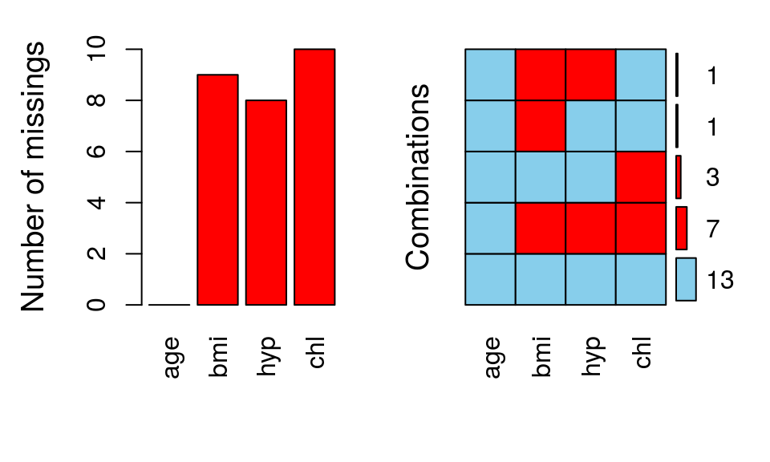

```r
aggr(nhanes, numbers = TRUE, prop = FALSE)
```

```r
p <- md.pairs(nhanes)
p$mr/(p$mr + p$mm)
```

```
    age bmi       hyp       chl
age NaN NaN       NaN       NaN
bmi   1 0.0 0.1111111 0.2222222
hyp   1 0.0 0.0000000 0.1250000
chl   1 0.3 0.3000000 0.0000000
```

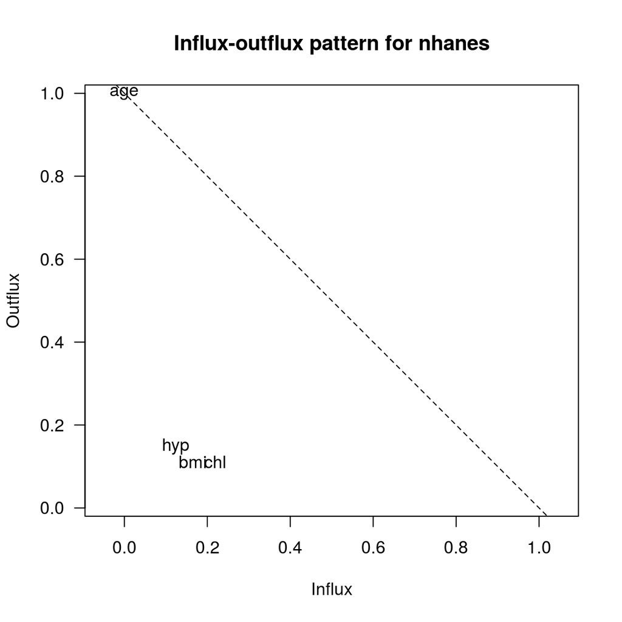

```r
fluxplot(nhanes)
```

## Predictors of missingness

```r
round(x = cor(x = nhanes,
              use = "pairwise.complete.obs"),
      digits = 2)
```

```
      age   bmi  hyp  chl
age  1.00 -0.37 0.51 0.51
bmi -0.37  1.00 0.05 0.37
hyp  0.51  0.05 1.00 0.43
chl  0.51  0.37 0.43 1.00
```

```r
pmA <- glm(is.na(chl) ~ age + bmi + hyp, family = binomial, data = nhanes)
pmB <- glm(is.na(bmi) ~ age + chl + hyp, family = binomial, data = nhanes)
pmC <- glm(is.na(hyp) ~ age + bmi + chl, family = binomial, data = nhanes)
txreg(list(pmA, pmB, pmC), custom.model.names = c("chl", "bmi", "hyp"))
```

Statistical models

|  | **chl** | **bmi** | **hyp** |
| --- | --- | --- | --- |
| (Intercept) | -9.18 | 14.75 | -24.57 |
|  | (8.61) | (9598.75) | (303112.73) |
| age | 1.72 | -18.21 | -0.00 |
|  | (1.36) | (6513.98) | (95787.74) |
| bmi | 0.20 |  | -0.00 |
|  | (0.26) |  | (13515.52) |
| hyp | -0.90 | -0.31 |  |
|  | (1.76) | (11600.34) |  |
| chl |  | 0.01 | 0.00 |
|  |  | (0.03) | (1497.48) |
| AIC | 21.19 | 13.55 | 8.00 |
| BIC | 24.28 | 16.10 | 10.26 |
| Log Likelihood | -6.60 | -2.77 | -0.00 |
| Deviance | 13.19 | 5.55 | 0.00 |
| Num. obs. | 16 | 14 | 13 |
| p < 0.001, p < 0.01, p < 0.05 |  |  |  |